# Factors Affecting Borrower APR

## By Tal Davidson

## Exploration Overview

In this investigation, we will delve into the variables that may impact a borrower's APR. Our primary focus will be on the initial loan amount, ProsperRating (Alpha), and Loan Term.

## Data Overview

The dataset encompasses 113,937 loans, each with 81 unique attributes such as loan amount, borrower rate (interest rate), current loan status, and borrower income.

## Borrower APR

The Borrower APR distribution exhibits multiple modes. It features a small peak around 0.09, a significant peak at 0.18, another small peak around 0.29, and a substantial peak between 0.35 and 0.36. Instances of APR exceeding 0.4 are rare. A higher APR indicates a greater interest rate on borrowed funds.

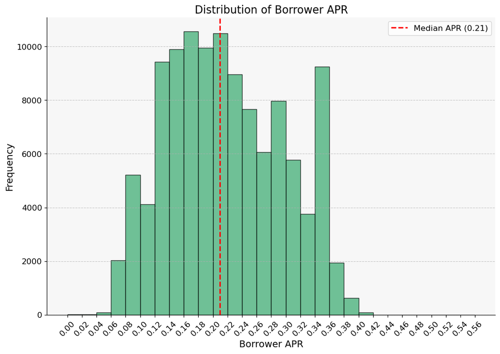

[figure not shown]

## Original Loan Amount

The highest loan frequency is around `$4,000`, followed by `$15,000` and `$10,000`, with additional peaks at `$2,000` and `$5,000`.

## ProsperRating (Alpha)

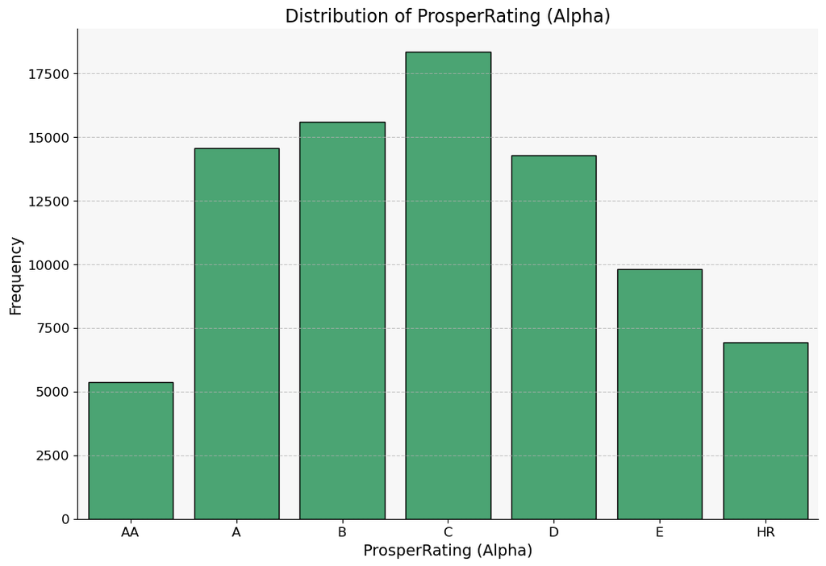

## Borrower APR vs. Original Loan Amount

There is a negative relationship between borrower APR and the original loan amount, meaning that as the loan amount increases, the APR tends to decrease.

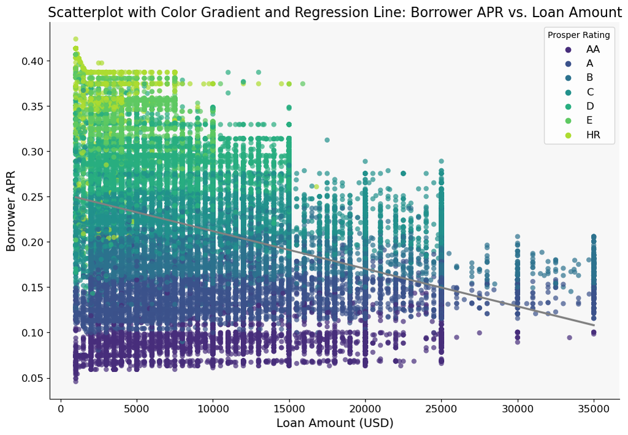

## Borrower APR by Loan Term and ProsperRating (Alpha)

- For AA-B ratings, the APR tends to increase with longer loan terms.
- Conversely, for C-HR ratings, the APR generally decreases with longer loan terms.

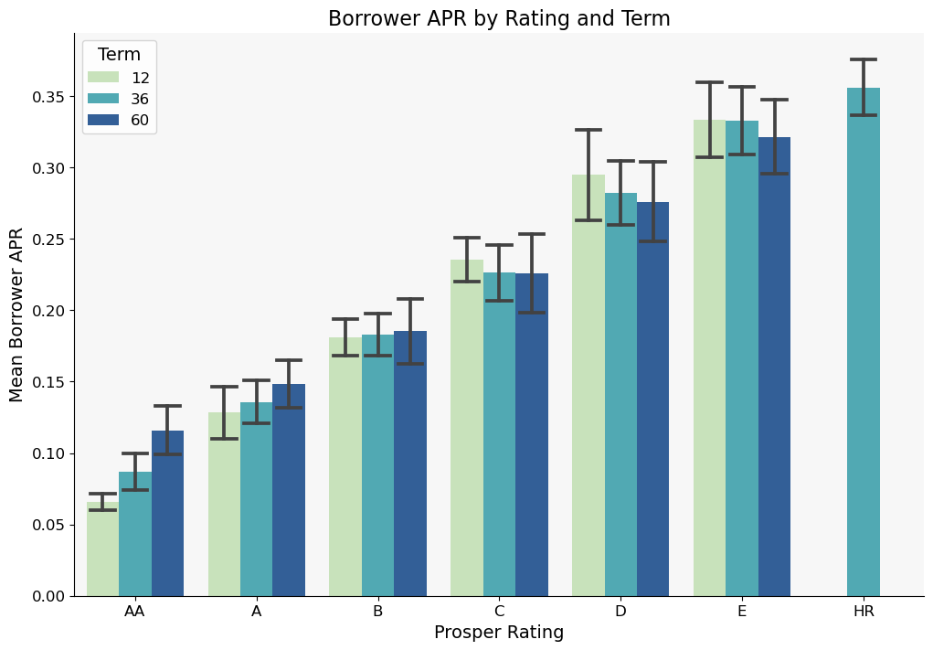